# Peer Assessment 1

Sergio Siqueira

August 9, 2014

This Reproducible Research Coursera course first assessment is based on data from Activity Monitoring Data file on the Github repository. The original file is compressed so it needs to be ‘unzipped’ to the R Studio working directory before load the .csv data file into the R environment to be processed.

The following code will perform these three steps:  
- Check if the file is into working directory, if not: issue a message, if yes, then  
- Uncompress the file into the same directory  
- Load the .csv file into R Studio and assure the date format

```r
## Check if file exists in working directory, if not then print a message asking to download the file to current WD
if (!file.exists("activity.zip")) {
      print("File 'activity.zip' does not exist in working directory, please download the file")
}

## Unzip the file, load into R and make sure date format
unzip("activity.zip")
activity <- read.csv("activity.csv", header = T, sep = ",")
activity$date <- as.Date(activity$date, format = "%Y-%m-%d")
```

Once data is loaded, sum steps for each day and discard the ‘NA’ values. The variable ‘steps_day’ holds the sum of steps for each day in the series. Function ‘rowsum’ discards all NA values in original ‘activity’ dataset.  
Following the total steps per day histogram with mean and median.

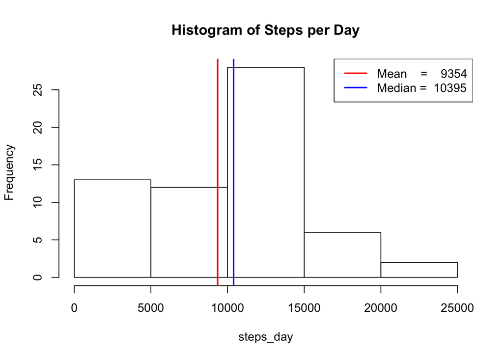

```r
## Sum of steps per day while removing NA values
steps_day <- rowsum(activity$steps, activity$date, reorder = F, na.rm = T)
hist(steps_day, main = "Histogram of Steps per Day")
abline(v = mean(steps_day), col = "red", lwd = 2)
abline(v = median(steps_day), col = "blue", lwd = 2)
legend("topright", c(paste("Mean    =   ", round(mean(steps_day))), paste("Median = ", median(steps_day))),
       col = c("red", "blue"), lwd = 2)
```

Now plot the time series: mean steps value per 5-minute intervals in each day. Need to remove the ‘NA’ values from original dataset, for that, I copied original dataset to an auxiliar set ‘aux_activity’ then split the auxiliar set in 5-minute intervals.

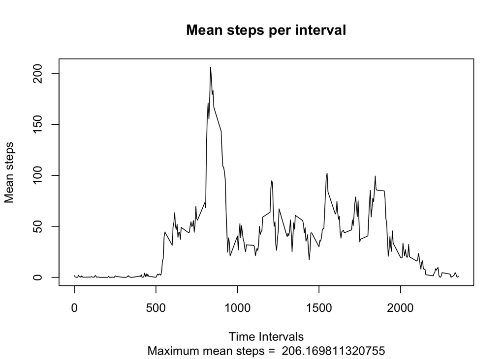

```r
# Removing NA from steps in activity dataframe
na_steps <- is.na(activity$steps)
aux_activity <- activity[!na_steps, , ]
interval_steps <- split(aux_activity$steps, aux_activity$interval)
interval_mean_steps <- lapply(interval_steps, mean)

## Identifying and plotting the Maximum value
max_value <- max(unlist(lapply(interval_mean_steps, max)))
plot(names(interval_mean_steps), interval_mean_steps, type = "l", main = "Mean steps per interval",
     sub = paste("Maximum mean steps = ", max_value), xlab = "Time Intervals", ylab = "Mean steps")
```

Next is to identify the number of missing values or ‘NA’ values in ‘steps’. The identification is based on ‘na_steps’ variable used in the previous “code chunk”.

```r
print(paste("Number of 'NA' values in activity$steps is ", sum(na_steps)))
```

```
## [1] "Number of 'NA' values in activity$steps is  2304"
```

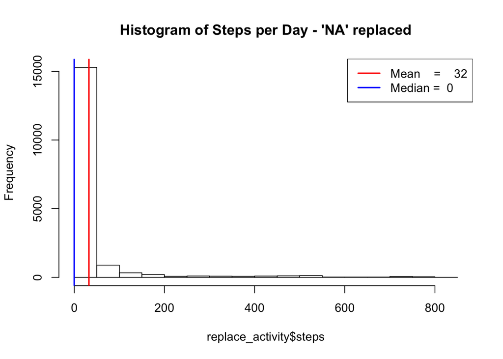

```r
# Using some variables created in previous chunks, create a variable with mean steps per day
day_steps <- split(aux_activity$steps, aux_activity$date)
day_mean_steps <- lapply(day_steps, mean)
# Replacing the 'NA' values
replace_activity <- activity
i <- 1
while(i <= nrow(replace_activity)) {
      if(is.na(replace_activity$steps[i])) {
            if(as.character(replace_activity$date[i]) %in% names(day_mean_steps)) {
                  replace_activity$steps[i] <- day_mean_steps[grep(as.character(replace_activity$date[i]), names(day_mean_steps))]
            }
            replace_activity$steps[i] <- 0
      }
      i <- i + 1
}
hist(replace_activity$steps, main = "Histogram of Steps per Day - 'NA' replaced")
abline(v = mean(replace_activity$steps), col = "red", lwd = 2)
abline(v = median(replace_activity$steps), col = "blue", lwd = 2)
legend("topright", c(paste("Mean    =   ", round(mean(replace_activity$steps))),
                     paste("Median = ", median(replace_activity$steps))),
       col = c("red", "blue"), lwd = 2)
```

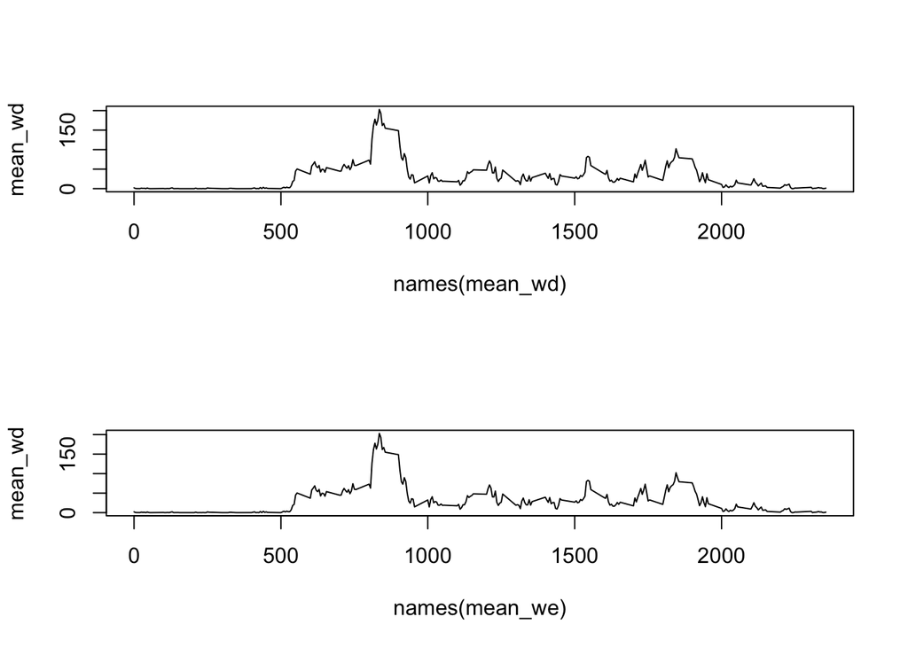

```r
replace_activity["weekday"] <- NA
replace_activity$weekday <- weekdays(as.Date(replace_activity$date), T)
act_weekdays <- subset(replace_activity, replace_activity$weekday %in% c("Mon", "Tue", "Wed", "Thu", "Fri"))
act_weekends <- subset(replace_activity, replace_activity$weekday %in% c("Sat", "Sun"))
interval_wd <- split(act_weekdays$steps, act_weekdays$interval)
interval_we <- split(act_weekends$steps, act_weekends$interval)
mean_wd <- lapply(interval_wd, mean)
mean_we <- lapply(interval_we, mean)
par(mfrow = c(2,1))
plot(names(mean_wd), mean_wd, type = "l")
plot(names(mean_we), mean_wd, type = "l")
```